# Boot Test

Odalys Barrientos

```r
library(readr)

UserIDs <- read_csv("Username-IDs/UserIDs.csv")
viral.users <- which(UserIDs$category == "Viral")

InfoM <- read_csv("transCSSR-master/InfoMeasuresData.csv")
InfoM$category <- UserIDs$category
InfoM <- InfoM[which(InfoM$category == "Famous" | InfoM$category == "ForYou" ),]

LL <- read_csv("transCSSR-master/LogLossDat.csv")
LL$category <- UserIDs$category
LL$Difference <- LL$LLGAM-LL$LLCSSR
# Positive = CSSR is better
# Negative = GAM is better
LL <- LL[which(LL$category == "Famous" | LL$category == "ForYou" ),]
```

# Boot Median function

```r
diff.medians <- function(x, i){
    xboot <- x[i,]
    group1.inds <- xboot$group == 1
    famous.scores <- xboot[group1.inds,1]
    group2.inds <- xboot$group == 2
    foryou.scores <- xboot[group2.inds,1]

    d.med <- median(famous.scores)-median(foryou.scores)
    return(d.med)
}
```

# LL Differences : t test

```r
library(MKinfer)
library(mosaic)
library(boot)

boot.t.test(Difference ~ category, data=LL)
```

```
    Bootstrapped Welch Two Sample t-test

data:  Difference by category
bootstrapped p-value = 0.5889
95 percent bootstrap percentile confidence interval:
 -0.008374611  0.014367207

Results without bootstrap:
t = 0.69523, df = 64.819, p-value = 0.4894
alternative hypothesis: true difference in means is not equal to 0
95 percent confidence interval:
 -0.00768483  0.01589170
sample estimates:
mean in group Famous mean in group ForYou
          0.01677871           0.01267528
```

bootstrapped p-value = 0.5943 95 percent bootstrap percentile confidence interval: -0.008311303 0.014436826 sample estimates: mean in group Famous | mean in group ForYou 0.01677871 | 0.01267528

Mean for difference in log loss in both groups are positive thus both famous and foryou groups prefer the CSSR model.

# LLGAM: Median

```r
scoresbygroup <- data.frame(score = LL$LLGAM, group = ifelse(LL$category=="Famous",1, 2))
scoresbygroup <- scoresbygroup[!is.na(scoresbygroup$score),]


b <- boot(data = scoresbygroup, statistic = diff.medians, R=2000, strata = scoresbygroup$group)

boot.ci(b, type = 'bca')
```

```
BOOTSTRAP CONFIDENCE INTERVAL CALCULATIONS
Based on 2000 bootstrap replicates

CALL :
boot.ci(boot.out = b, type = "bca")

Intervals :
Level       BCa
95%   (-0.0138,  0.0387 )
Calculations and Intervals on Original Scale
```

```r
diff.medians(scoresbygroup, i = 1:nrow(scoresbygroup))
```

```
[1] 0.01627438
```

```r
aggregate(score ~ group, data = scoresbygroup, FUN = median)$score
```

```
[1] 0.06478072 0.04850635
```

# LLGAM: Mean

```r
boot.t.test(LLGAM ~ category, data=LL)
```

```
    Bootstrapped Welch Two Sample t-test

data:  LLGAM by category
bootstrapped p-value = 0.1462
95 percent bootstrap percentile confidence interval:
 -0.005789609  0.049601859

Results without bootstrap:
t = 1.497, df = 97.087, p-value = 0.1376
alternative hypothesis: true difference in means is not equal to 0
95 percent confidence interval:
 -0.006948571  0.049608553
sample estimates:
mean in group Famous mean in group ForYou
          0.08775446           0.06642447
```

bootstrapped p-value = 0.1328 95 percent bootstrap percentile confidence interval: -0.006077797 0.049560263 sample estimates: mean in group Famous | mean in group ForYou 0.08775446 | 0.06642447

Mean in group Famous is slightly higher (by 0.021). In this sample, the famous group has a higher log loss as opposed to the ForYou group. We do not have statistically significant pvalue, thus there is not enough evidence that there is a true difference between the log loss for the GAM model for the famous vs ForYou group.

# LLCSSR: Median

```r
scoresbygroup <- data.frame(score = LL$LLCSSR, group = ifelse(LL$category=="Famous",1, 2))
scoresbygroup <- scoresbygroup[!is.na(scoresbygroup$score),]


b <- boot(data = scoresbygroup, statistic = diff.medians, R=2000, strata = scoresbygroup$group)

boot.ci(b, type = 'bca')
```

```
BOOTSTRAP CONFIDENCE INTERVAL CALCULATIONS
Based on 2000 bootstrap replicates

CALL :
boot.ci(boot.out = b, type = "bca")

Intervals :
Level       BCa
95%   (-0.0066,  0.0338 )
Calculations and Intervals on Original Scale
```

```r
diff.medians(scoresbygroup, i = 1:nrow(scoresbygroup))
```

```
[1] 0.01422895
```

```r
aggregate(score ~ group, data = scoresbygroup, FUN = median)$score
```

```
[1] 0.05893908 0.04471013
```

# LLCSSR

```r
boot.t.test(LLCSSR ~ category, data=LL)
```

```
    Bootstrapped Welch Two Sample t-test

data:  LLCSSR by category
bootstrapped p-value = 0.11
95 percent bootstrap percentile confidence interval:
 -0.003569262  0.039467437

Results without bootstrap:
t = 1.5423, df = 97.564, p-value = 0.1262
alternative hypothesis: true difference in means is not equal to 0
95 percent confidence interval:
 -0.004939764  0.039392873
sample estimates:
mean in group Famous mean in group ForYou
          0.07097575           0.05374919
```

bootstrapped p-value = 0.1064 95 percent bootstrap percentile confidence interval: -0.003564687 0.039631635 sample estimates: mean in group Famous | mean in group ForYou 0.07097575 | 0.05374919

Mean in group Famous is slightly higher (by 0.017)(could this inidcate the famous group is a harder group to predict???). In this sample, the famous group has a higher log loss as opposed to the ForYou group. We do not have statistically significant pvalue, thus there is not enough evidence that there is a true difference between the log loss for the CSSR model for the famous vs ForYou groups.

# Hmu: Median

```r
scoresbygroup <- data.frame(score = InfoM$Hmu, group = ifelse(InfoM$category=="Famous",1, 2))
scoresbygroup <- scoresbygroup[!is.na(scoresbygroup$score),]


b <- boot(data = scoresbygroup, statistic = diff.medians, R=2000, strata = scoresbygroup$group)

boot.ci(b, type = 'bca')
```

```
BOOTSTRAP CONFIDENCE INTERVAL CALCULATIONS
Based on 2000 bootstrap replicates

CALL :
boot.ci(boot.out = b, type = "bca")

Intervals :
Level       BCa
95%   (-0.0417,  0.0340 )
Calculations and Intervals on Original Scale
```

```r
diff.medians(scoresbygroup, i = 1:nrow(scoresbygroup))
```

```
[1] -0.004822241
```

```r
aggregate(score ~ group, data = scoresbygroup, FUN = median)$score
```

```
[1] 0.06212044 0.06694268
```

## Bootstrapped Confidence Curve

```r
# Uncomment to install:

# devtools::install_github('ddarmon/clp')
```

```r
library(clp)
```

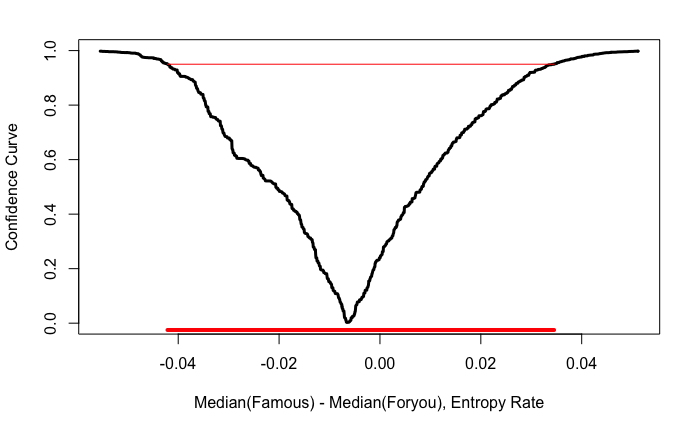

```r
boot.out <- clp::bcaboot(scoresbygroup, diff.medians, stratified = TRUE, B = 10000)

cfs <- clp::conffuns.from.bcaboot(boot.out)

display.cconf(cfs, xlab = 'Median(Famous) - Median(Foryou), Entropy Rate')
```

# Hmu : Entropy Rate (Randomness (1 = random))

```r
boot.t.test(Hmu ~ category, data = InfoM)
```

```
    Bootstrapped Welch Two Sample t-test

data:  Hmu by category
bootstrapped p-value = 0.5515
95 percent bootstrap percentile confidence interval:
 -0.02061182  0.03963027

Results without bootstrap:
t = 0.5917, df = 95.109, p-value = 0.5555
alternative hypothesis: true difference in means is not equal to 0
95 percent confidence interval:
 -0.02187640  0.04045416
sample estimates:
mean in group Famous mean in group ForYou
          0.09467219           0.08538331
```

bootstrapped p-value = 0.5461 95 percent bootstrap percentile confidence interval: -0.02135636 0.04021306 sample estimates: mean in group Famous | mean in group ForYou 0.09467219 | 0.08538331

Mean in group Famous is slightly higher (by 0.009) (the difference is basically nothing but in this sample famous users have a slighly higher entropy rate so their behavior is slightly more random than ForYou users)

In this sample, the famous group has a higher entropy rate as opposed to the ForYou group. We do not have statistically significant pvalue, thus there is not enough evidence that there is a true difference between the entropy rate for the famous vs ForYou groups.

## Confidence Curve for Difference in Means

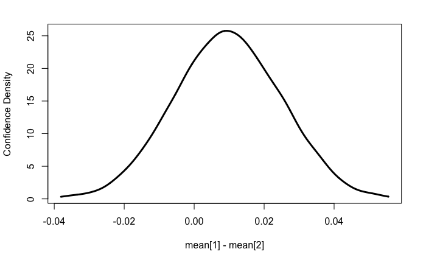

[output not shown]

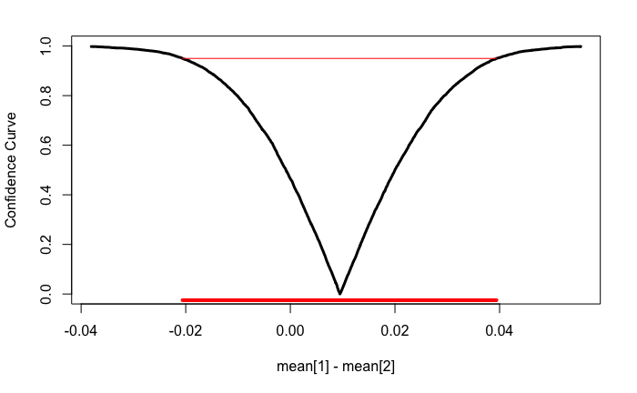

```r
clp::t_test.boot.conf(scoresbygroup$score[scoresbygroup$group == 1],
                 scoresbygroup$score[scoresbygroup$group == 2],
                 B = 10000)
```

# E: Median

```r
scoresbygroup <- data.frame(score = InfoM$E, group = ifelse(InfoM$category=="Famous",1, 2))
scoresbygroup <- scoresbygroup[!is.na(scoresbygroup$score),]


b <- boot(data = scoresbygroup, statistic = diff.medians, R=2000, strata = scoresbygroup$group)

boot.ci(b, type = 'bca')
```

```
BOOTSTRAP CONFIDENCE INTERVAL CALCULATIONS
Based on 2000 bootstrap replicates

CALL :
boot.ci(boot.out = b, type = "bca")

Intervals :
Level       BCa
95%   (-0.0041,  0.0008 )
Calculations and Intervals on Original Scale
```

```r
diff.medians(scoresbygroup, i = 1:nrow(scoresbygroup))
```

```
[1] -0.0008837631
```

```r
aggregate(score ~ group, data = scoresbygroup, FUN = median)$score
```

```
[1] 0.0001688521 0.0010526151
```

## Bootstrapped Confidence Curve

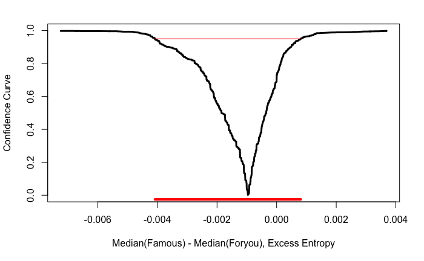

```r
boot.out <- clp::bcaboot(scoresbygroup, diff.medians, stratified = TRUE, B = 10000)

cfs <- clp::conffuns.from.bcaboot(boot.out)

display.cconf(cfs, xlab = 'Median(Famous) - Median(Foryou), Excess Entropy')
```

# E: Memory

```r
boot.t.test(E ~ category, data = InfoM)
```

```
    Bootstrapped Welch Two Sample t-test

data:  E by category
bootstrapped p-value = 0.7451
95 percent bootstrap percentile confidence interval:
 -0.3723644  0.5648051

Results without bootstrap:
t = 0.32914, df = 98.918, p-value = 0.7427
alternative hypothesis: true difference in means is not equal to 0
95 percent confidence interval:
 -0.3921057  0.5480563
sample estimates:
mean in group Famous mean in group ForYou
           0.2722178            0.1942425
```

bootstrapped p-value = 0.7361 95 percent bootstrap percentile confidence interval: -0.3706005 0.5630562 sample estimates: mean in group Famous | mean in group ForYou 0.2722178 | 0.1942425

(the difference is basically is very small but famous users tend to need more memory than forYou users) In this sample, the famous group has a higher E as opposed to the ForYou group. We do not have statistically significant pvalue, thus there is not enough evidence that there is a true difference between E for the famous vs ForYou groups.

## Confidence Curve for Difference in Means

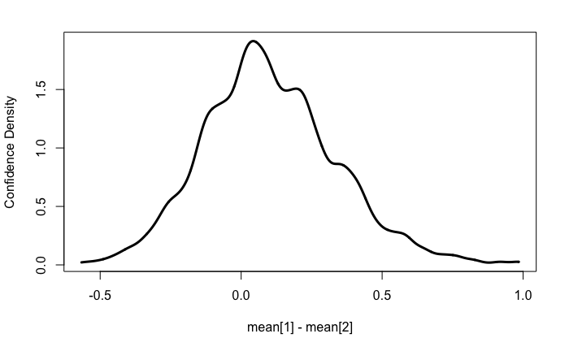

[output not shown]

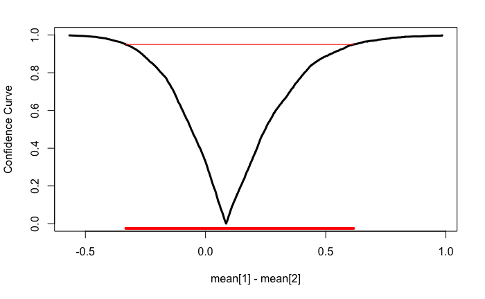

```r
clp::t_test.boot.conf(scoresbygroup$score[scoresbygroup$group == 1],
                 scoresbygroup$score[scoresbygroup$group == 2],
                 B = 10000)
```

# Cmu: Median

```r
scoresbygroup <- data.frame(score = InfoM$Cmu, group = ifelse(InfoM$category=="Famous",1, 2))
scoresbygroup <- scoresbygroup[!is.na(scoresbygroup$score),]


b <- boot(data = scoresbygroup, statistic = diff.medians, R=2000, strata = scoresbygroup$group)

boot.ci(b, type = 'bca')
```

```
BOOTSTRAP CONFIDENCE INTERVAL CALCULATIONS
Based on 2000 bootstrap replicates

CALL :
boot.ci(boot.out = b, type = "bca")

Intervals :
Level       BCa
95%   (-0.2468,  0.0626 )
Calculations and Intervals on Original Scale
```

```r
diff.medians(scoresbygroup, i = 1:nrow(scoresbygroup))
```

```
[1] -0.06233366
```

```r
aggregate(score ~ group, data = scoresbygroup, FUN = median)$score
```

```
[1] 0.02312766 0.08546132
```

## Bootstrapped Confidence Curve

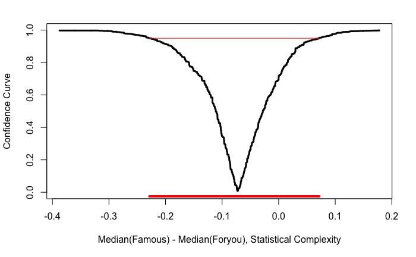

```r
boot.out <- clp::bcaboot(scoresbygroup, diff.medians, stratified = TRUE, B = 10000)

cfs <- clp::conffuns.from.bcaboot(boot.out)

display.cconf(cfs, xlab = 'Median(Famous) - Median(Foryou), Statistical Complexity')
```

# Cmu:

```r
boot.t.test(Cmu ~ category, data = InfoM)
```

```
    Bootstrapped Welch Two Sample t-test

data:  Cmu by category
bootstrapped p-value = 0.3782
95 percent bootstrap percentile confidence interval:
 -0.3044286  0.1038012

Results without bootstrap:
t = -0.79345, df = 68.271, p-value = 0.4303
alternative hypothesis: true difference in means is not equal to 0
95 percent confidence interval:
 -0.2897304  0.1248650
sample estimates:
mean in group Famous mean in group ForYou
           0.2380611            0.3204938
```

bootstrapped p-value = 0.3852 95 percent bootstrap percentile confidence interval: -0.2930788 0.1032197 sample estimates: mean in group Famous | mean in group ForYou 0.2380611 | 0.3204938

Mean in group ForYou is slightly higher (by 0.082) The difference is small but in this sample of users we can see that the users in the ForYou group have slightly more complaicated models than famous users.

## Confidence Curve for Difference in Means

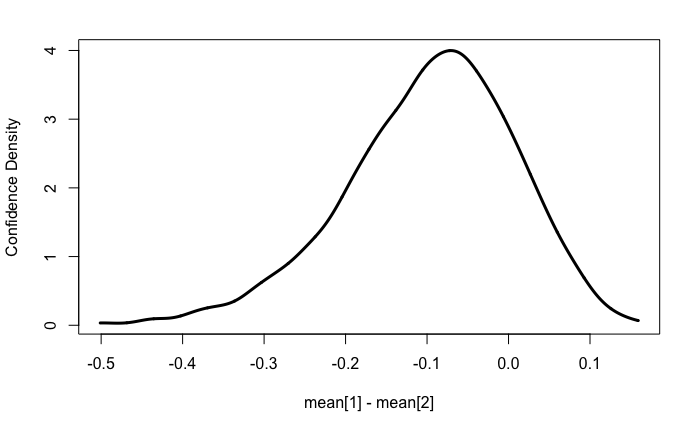

[output not shown]

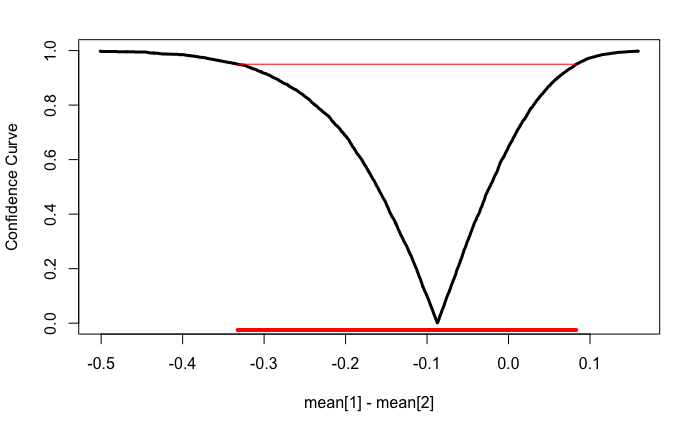

```r
clp::t_test.boot.conf(scoresbygroup$score[scoresbygroup$group == 1],
                 scoresbygroup$score[scoresbygroup$group == 2],
                 B = 10000)
```

# Overall

There are no statistically significant differences between the famous group and foryou group when looking at log loss (tells us which model fits best) and looking and the information measures (from CSSR).

From sample means we can see that in our sample famous users have more random behavior and less complicated models where foryou users have less random behavior and more complicated models. Also famous groups have to use more “memory” (E) than foryou users in order to model the users behavior.